# dci User Guide

```r
library(dci)
library(dplyr)
```

The dci package provides an R interface for the measurement of connectivity in river networks with the dendritic connectivity index (Cote et al., 2009). The main class of the package is the river_net class which links river lines to barriers and the outlet of the river network. It inherits the structure of the sfnetwork class from the [sfnetworks package](https://luukvdmeer.github.io/sfnetworks/) which itself inherits the tbl_graph class from the [tidygraph package](https://tidygraph.data-imaginist.com/index.html) further inherited by the igraph class from the [igraph package](https://igraph.org/). These dependencies on other packages provide a rich set of tools and algorithms which remain applicable to all instances of the river_net class. Therefore, further and more complex analyses can be carried out with functions from the `igraph`, `tidygraph`, and `sfnetworks` packages. Further, the tbl_graph class from `tidygraph` is created with the [tidyverse](https://tidyverse.org/) in mind and, thus, allows for the development of workflows using `tidyverse` packages.

This vignette illustrates the `dci` package using river and barrier data from the Yamaska watershed in Southern Quebec.

## Required data

DCI analysis with the `dci` package requires three pieces of spatial data:

- *River lines*: Data representing river lines which will make up the edges of the spatial network. The `import_rivers` function of the package will extract the largest fully connected component of the provided data and other isolated rivers will be discarded.
- *Barrier points*: Points representing barriers along the river network. Points are not required to be perfectly snapped to the river lines, the tolerance parameter of the `river_net` function can perform this snapping.
- *Outlet point*: A single point representing the downstream outlet of the river network. This point should be accurate for the calculation of the diadromous DCI.

## Importing

A `river_net` object is constructed using three pieces of required data: river lines, barrier points, and the outlet location. These input spatial data must first be imported with `import_rivers` and `import_points` functions.

```r
# Load Yamaska river data
data("yamaska_rivers", package = "dci")
# Import rivers
rivers_in <- import_rivers(rivers = yamaska_rivers)
```

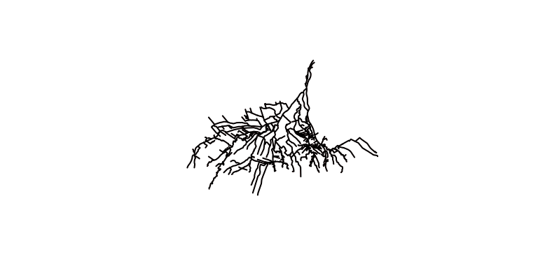

Similarly, all point data can be imported with the `import_points` function along with the `type` parameter specifying the type of point. Possible values are: “bars” for barriers and “out” for the outlet.

```r
# Load Yamaska barrier and outlet data
data("yamaska_barriers", package = "dci")
data("yamaska_outlet", package = "dci")
# Import barriers
barriers_in <- import_points(pts = yamaska_barriers, type = "bars")
outlet_in <- import_points(pts = yamaska_outlet, type = "out")
barriers_in
```

```
#> Simple feature collection with 14 features and 3 fields
#> Geometry type: POINT
#> Dimension:     XY
#> Bounding box:  xmin: -353726.8 ymin: 233223.5 xmax: -337065.2 ymax: 241340.8
#> Projected CRS: NAD83 / Quebec Lambert
#> # A tibble: 14 × 4
#>    pass_1 pass_2             geometry type
#>  *  <dbl>  <dbl>          <POINT [m]> <chr>
#>  1    0.3      0 (-353726.8 237532.9) barrier
#>  2    0.5      0 (-352055.2 236475.2) barrier
#>  3    0.1      0 (-351647.6 233223.5) barrier
#>  4    0.6      0 (-349660.2 235578.7) barrier
#>  5    0.8      0 (-349237.3 237746.8) barrier
#>  6    0.9      0 (-349254.4 239658.6) barrier
#>  7    0.8      0 (-344910.5 241340.8) barrier
#>  8    0.7      0 (-344990.2 239352.8) barrier
#>  9    0.4      0 (-343315.7 236427.2) barrier
#> 10    0.3      0 (-339418.4 235113.6) barrier
#> 11    0.9      0   (-337065.2 235843) barrier
#> 12    0.5      0 (-345792.5 233877.2) barrier
#> 13    0.6      0 (-346344.7 234715.3) barrier
#> 14    0.6      0 (-347463.1 234803.6) barrier
```

## Network construction

Once all required data have been pre-processed with the import functions they can be joined together in the `river_net` function to generate an object of the `river_net` class. Messages are printed indicating the topological corrections that are being performed on the river network. These are explained in more detail in the next section. Additionally, this function will split rivers at new barrier node locations.

```r
# Combine rivers, barriers, and outlet
# Warnings about river splitting suppressed since rivers are already split at barrier node locations
net <- suppressWarnings(
  river_net(rivers = rivers_in, barriers = barriers_in, outlet = outlet_in)
)
```

[output not shown]

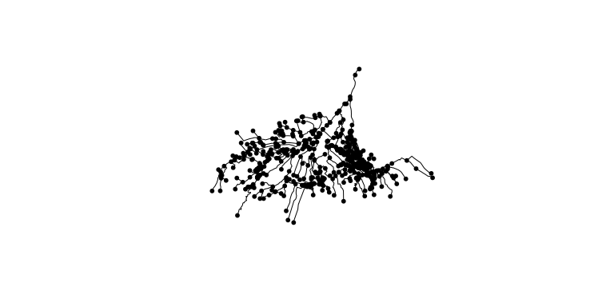

```r
plot(net)
```

### Dendritic topology

Since the `river_net` class inherits from the `sfnetworks` class it shares the enforcement of certain network rules from the `sfnetworks` package: nodes should have `POINT` geometries, edges should be spatially explicit and have “LINESTRING” geometries, and both nodes and edges should have the same CRS. In addition to these, the `dci` package enforces additional rules pertaining to the dendritic topology of river networks. A dendritic topology is defined as a directional network topology in which at most two upstream edges combine at a node to form a single outgoing downstream edge. In the case of a barrier there would be one incoming edge while in the case of natural confluences two incoming edges combine. This topological rule is enforced because it allows for the design of custom river network path finding algorithms which run quicker than traditional network algorithms. This is explained in more detail in the labeling section.

The `river_net` provides functionality for correcting some common topological errors. These errors are illustrated below:

1. *Divergent rivers* - Divergent rivers occur where a single upstream river splits into two downstream rivers. This often occurs because of large obstacles in the waterway of large rivers causing a single river to split and recombine further downstream. If the `river_net` function is run with the `clean` parameter set to `TRUE` divergences are corrected by deleting the shortest of the two downstream rivers. If more fine-tuned corrections are preferred the `enforce_dendritic` function can be called directly on the rivers imported by `import_rivers`. This functionality is illustrated below.
2. *Complex confluences* - Complex confluences occur when a confluence node has over 3 incident edges. These often occur as a limitation of data resolution where two very close confluences merge into one. If the `river_net` function is run with the `clean` parameter set to `TRUE` complex confluences are corrected by moving one of the incident edges further downstream on the main channel. When a complex confluence is present with over 4 incident edges the function will quit and a manual correction will be required.

By default the `river_net` constructor performs these topological corrections automatically. However, if manual corrections are desired the `enforce_dendritic` function can be called directly with the river lines data and the `correct` parameter set to `FALSE`. Then, when constructing the `river_net` object, the `check` parameter can be set to `FALSE` since the topology has already been corrected.

```r
# Identify topological errors in rivers
river_errors <- enforce_dendritic(rivers = rivers_in, correct = FALSE)
```

```
#> 27 divergences have been found.
#> 7 complex confluences found.
```

```r
river_errors
```

```
#> Simple feature collection with 620 features and 4 fields
#> Geometry type: LINESTRING
#> Dimension:     XY
#> Bounding box:  xmin: -357300.6 ymin: 230498.2 xmax: -335432.5 ymax: 245955.3
#> Projected CRS: NAD83 / Quebec Lambert
#> # A tibble: 620 × 5
#>     qual riv_length                                 geometry complexID divergent
#>    <dbl>      <dbl>                         <LINESTRING [m]>     <int>     <int>
#>  1     3      262.  (-347139.6 241142.8, -347058.6 240893.6)        NA        NA
#>  2     5       51.8 (-346605.8 241063.7, -346602.3 241061.8…         1         3
#>  3     1      501.  (-347058.6 240893.6, -347052.4 240896.2…         1        NA
#>  4     8     1345.  (-348305.1 240996.5, -348304.5 240994.9…        NA        NA
#>  5     7       75.4 (-344551 237776.1, -344566.4 237776, -3…        NA        NA
#>  6     7      599.  (-344048.9 237965.3, -344620.7 237788.2)        NA        NA
#>  7     6      204.  (-342723.6 236820.6, -342727.1 236872, …        NA        NA
#>  8     3       59.3 (-354145.2 237109.7, -354140.1 237111.4…        NA        NA
#>  9     0      475.  (-354088.8 237127.9, -354066.1 237137.3…        NA        NA
#> 10     5      323.  (-354207.6 237379.7, -354219.2 237343.4…        NA        NA
#> # ℹ 610 more rows
```

In the above example a manual dendritic correction is requested which returns the input river lines augmented with a `divergent` variable which links divergent rivers from the same pair and a `complex` variable which indicates which rivers take part in complex confluences. These variables can then be used in a dedicated GIS software or R and the corrected rivers can be used to construct a `river_net` object. This manual correction might be beneficial in situations where an important barrier or point of interest is lost during automatic correction.

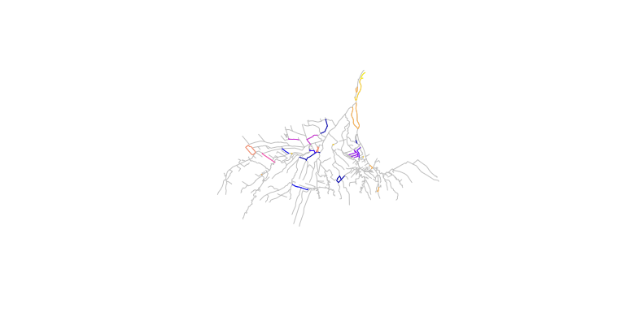

```r
# Visualize divergence locations
plot(sf::st_geometry(rivers_in), col = "grey75")
plot(river_errors["divergent"], add = TRUE)
```

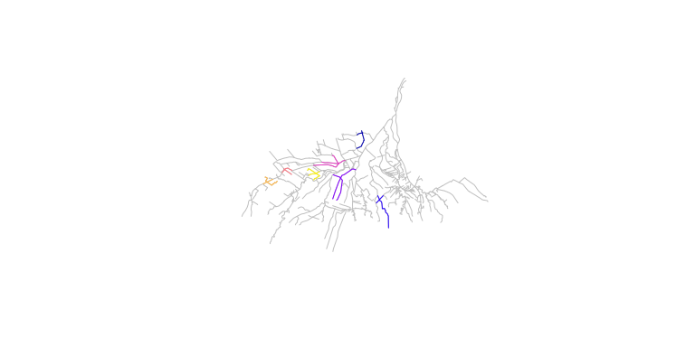

```r
# Visualize complex confluence locations
plot(sf::st_geometry(rivers_in), col = "grey75")
plot(river_errors["complexID"], add = TRUE)
```

### Labeling

There are 2 types of labeling performed on a `river_net` object.

1. Node labeling - Node labeling makes use of a binary code to, essentially, give an address to each node in the network relative to the outlet. Labeling begins at the outlet with a label of 0 and proceeds upstream. At the first split, the two children of the outlet node are given labels 00 and 01. These labels allow for rapid path tracing in river networks to gather the watercourse distance between two nodes or the passability of barriers which lie on that path. The task of finding the least-cost path between points is a computationally intensive network theory problem and it’s an important one when considering connectivity in terrestrial landscapes. However, river networks which follow a dendritic topology exhibit an important property - there is only one path between any two points in the network. Common path-finding algorithms like Djikstra’s algorithm are made to be general and don`t make these types of assumptions about network structure. This labeling allows for the design of custom, rapid algorithms to gather the path between nodes in the network.
2. Membership labeling - Membership labeling is much more simple than the node labeling. Membership labels simply classify nodes into specific isolated river segments bounded on all sides by either barriers or terminal nodes of the network (sources and the outlet). These labels are simply integers from 0 to the number of segments.

## Calculating the DCI

Once a valid `river_net` object is constructed all the elements are present to calculate the DCI. The DCI comes in a few flavours and they can all be derived from the single `calculate_dci` function. The parameters of the function will dictate what type of connectivity is being estimated:

- the `form` parameter - The form of the DCI relates to the dispersal style of the target organism. The accepted forms are “potamodromous” and “diadromous”. This will dictate the form of the DCI equation that is calculated, more details can be found in (Cote et al., 2009). This is the only parameter that is required to calculate the DCI.
- the `pass` parameter - The `pass` parameter allows for the selection of a relevant passability variable in the barrier data. Passability probabilities for barriers must range from 0 to 1. If they are not within that range the data will automatically be normalized. If the parameter is left blank all barriers will receive a passability of 0.
- the `weight` parameter - Similar to the `pass` parameter, the `weight` parameter allows for the selection of a relevant weighting variable in the river data. Again, these values are required to be between 0 and 1 since they are applied to the river lengths. Weights of 0 will fully exclude rivers while weights of 1 will fully include them. A possible application is to use habitat suitability estimates as river weighting to achieve a more specific measure of landscape connectivity for a species.
- the `threshold` parameter - The `threshold` parameter gives the option of considering a dispersal limit when calculating the DCI. The thresholded DCI prunes any connections between segments that are further away than the dispersal limit. The non-thresholded DCI can be thought of the DCI calculated with a dispersal limit of infinity.

In the example below the DCI is calculated for a potamodromous species. No weighting is used in this case. The global DCI is printed and a dataframe is returned containing each segment’s contribution to that global DCI - these are the segmental DCI scores.

```r
yamaska_res <- calculate_dci(net = net,
                             form = "pot",
                             pass = "pass_1",
                             weight = NULL,
                             threshold = NULL)
```

```
#> potamodromous DCI: 55.9457980804545
```

```r
yamaska_res
```

```
#>    segment         DCI     DCI_rel
#> 1        0 12.56427348 22.45793950
#> 2        1  0.67342410  1.20370809
#> 3        2  0.19304043  0.34504902
#> 4        3  2.66030823  4.75515288
#> 5        4  3.03190313  5.41935808
#> 6        5 23.97697527 42.85750868
#> 7        6  0.39179792  0.70031697
#> 8        7  0.12409826  0.22181873
#> 9        8  2.63413959  4.70837789
#> 10       9  1.14102462  2.03951799
#> 11      10  2.78996621  4.98690930
#> 12      11  0.02468512  0.04412328
#> 13      12  2.57142913  4.59628643
#> 14      13  1.79670689  3.21151355
#> 15      14  1.37202572  2.45241960
```

The `calculate_dci` function returns a table where each river segment is assigned a raw DCI score along with a standardized relative DCI score. The raw scores are useful when comparisons are desired between different watersheds. On the other hand, the relative scores allow for a clearer picture of differences within a watershed. An additional function, `export_dci`, is provided to rejoin these results to the original line or point data. This is explained in the next section.

### Distance thresholds

The `threshold` parameter of the `calculate_dci` function allows for the inclusion of a distance threshold above which river fragments aren’t considered connected. In terms of the DCI equation, this would mean that not all pairs of segments will participate in the summation. In addition, the threshold distance is used to generate an additional weighting term based on the amount of habitat in the source fragment that can be considered connected to the exit node. This is done by generating an isodistance map around the source fragment`s exit node and gathering the total distance of rivers from the source fragment within that isodistance map. This length is then divided by the total length of the river network.

The use of a distance threshold can be useful to derive a clearer picture of connectivity when a species` dispersal limit is known. Below is an example done with the same Yamaska watershed using a distance threshold of 1.5km. This distance is written in the default map units which are meters.

```r
yamaska_res_thr <- calculate_dci(net = net,
                            form = "pot",
                            pass = "pass_1",
                            weight = NULL,
                            threshold = 1500)
```

```
#> potamodromous DCI with distance limit of 1500: 20.8405089609362
```

```r
yamaska_res_thr
```

```
#>    segment         DCI     DCI_rel
#> 1        0  3.72060622 17.85276083
#> 2        1  0.12702332  0.60950202
#> 3        2  0.06085524  0.29200457
#> 4        3  0.52654957  2.52656770
#> 5        4  1.12481798  5.39726732
#> 6        5 11.61246233 55.72062734
#> 7        6  0.19000695  0.91171932
#> 8        7  0.02638980  0.12662744
#> 9        8  0.66217202  3.17733132
#> 10       9  0.45759080  2.19567957
#> 11      10  0.70825539  3.39845535
#> 12      11  0.00516824  0.02479901
#> 13      12  0.73075801  3.50643072
#> 14      13  0.52481637  2.51825124
#> 15      14  0.36303672  1.74197624
```

### River weights

An additional option with the DCI calculation is to include a weighting term with the river data. By default the DCI only considers the length of rivers as a measure of amount of habitat. However, certain cases might benefit from a more specific definition of amount of habitat. The `weight` parameter of the `calculate_dci` function can use one of the variables included with the river data as a weighting term applied to the river lengths. These values are rescaled between 0 and 1 before applying the weighting. An example using a habitat suitability weighting is demonstrated below.

```r
yamaska_res_w <- calculate_dci(net = net,
                             form = "pot",
                             pass = "pass_1",
                             weight = "qual",
                             threshold = NULL)
```

```
#> potamodromous DCI: 55.8242406562483
```

```r
yamaska_res_w
```

```
#>    segment         DCI     DCI_rel
#> 1        0 13.03629720 23.35239503
#> 2        1  1.34188653  2.40377033
#> 3        2  0.22867504  0.40963395
#> 4        3  3.23684297  5.79827497
#> 5        4  3.97779632  7.12557175
#> 6        5 22.64545088 40.56562276
#> 7        6  0.51185358  0.91690199
#> 8        7  0.13546608  0.24266533
#> 9        8  3.13011120  5.60708245
#> 10       9  0.98917111  1.77193832
#> 11      10  2.55680391  4.58009617
#> 12      11  0.01010649  0.01810412
#> 13      12  1.93304252  3.46272962
#> 14      13  1.20238210  2.15387094
#> 15      14  0.88835474  1.59134227
```

## Extracting results

A convenient `export_dci` function is included in this package to simplify the exporting of dci results with the original `river_net` inputs. The function will return the specified type of data: either rivers, barriers, or points of interest, along with the appropriately joined DCI scores for different locations. Along with returning the spatial data requested, the function will produce a simple plot of the results. The plots always indicate the raw DCI scores. The functionality of this code is presented below.

```r
# Results can be rejoined to the river lines
res_riv <- export_dci(net = net, results = yamaska_res, type = "rivers")
```

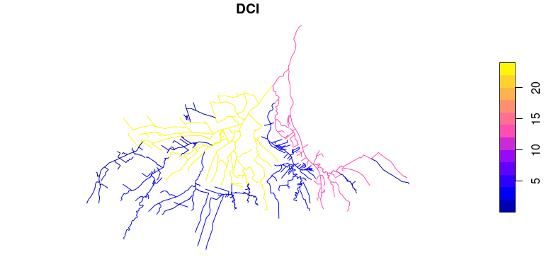

```r
# Results can also be rejoined to the barriers
res_bar <- export_dci(net = net, results = yamaska_res, type = "bars")
```

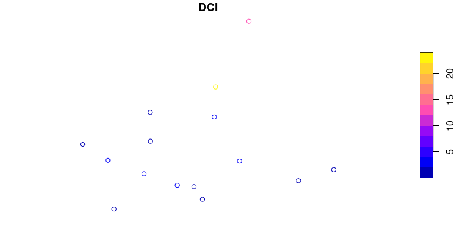

## Visualizing results

More sophisticated visualization of river networks and the results of the DCI analysis are beyond the scope of this package. However, some code to visualize these networks and DCI results with the ggplot2 package is provided below.

```r
# Visualize river network with nodes coloured according to their type
ggplot() +
  geom_sf(data = net %>% tidygraph::activate(edges) %>% sf::st_as_sf()) +
  geom_sf(data = net %>% tidygraph::activate(nodes) %>% sf::st_as_sf(), aes(col = type))

# Visualize the DCI color coded river network with the barriers
ggplot() +
  geom_sf(data = res_riv, aes(col = DCI)) +
  geom_sf(data = net %>% tidygraph::activate(nodes) %>% sf::st_as_sf() %>% dplyr::filter(type == "barrier"))
```

[output not shown]

## References

Cote, D., Kehler, D. G., Bourne, C., & Wiersma, Y. F. (2009). A new measure of longitudinal connectivity for stream networks. Landscape Ecology, 24(1), 101-113.